# MGT 205 Project 3

KEMAN XIANG

```r
library(tidyverse)
heart <- read_csv('heart.csv')
head(heart)
```

```
## # A tibble: 6 × 14
##     age   sex    cp trestbps  chol   fbs restecg thalach exang oldpeak slope
##   <dbl> <dbl> <dbl>    <dbl> <dbl> <dbl>   <dbl>   <dbl> <dbl>   <dbl> <dbl>
## 1    63     1     3      145   233     1       0     150     0     2.3     0
## 2    37     1     2      130   250     0       1     187     0     3.5     0
## 3    41     0     1      130   204     0       0     172     0     1.4     2
## 4    56     1     1      120   236     0       1     178     0     0.8     2
## 5    57     0     0      120   354     0       1     163     1     0.6     2
## 6    57     1     0      140   192     0       1     148     0     0.4     1
## # ℹ 3 more variables: ca <dbl>, thal <dbl>, target <dbl>
```

# Data Description and Usage

- **age:** The person’s age in years
- **sex:** The person’s sex (1 = male, 0 = female)
- **cp:** The chest pain experienced (Value 1: typical angina, Value 2: atypical angina, Value 3: non-anginal pain, Value 4: asymptomatic)
- **trestbps:** The person’s resting blood pressure (mm Hg on admission to the hospital)
- **chol:** The person’s cholesterol measurement in mg/dl
- **fbs:** The person’s fasting blood sugar (> 120 mg/dl, 1 = true; 0 = false)
- **restecg:** Resting electrocardiographic measurement (0 = normal, 1 = having ST-T wave abnormality, 2 = showing probable or definite left ventricular hypertrophy by Estes’ criteria)
- **thalach:** The person’s maximum heart rate achieved
- **exang:** Exercise induced angina (1 = yes; 0 = no)
- **oldpeak:** ST depression induced by exercise relative to rest (‘ST’ relates to positions on the ECG plot. See more here)
- **slope:** the slope of the peak exercise ST segment (Value 1: upsloping, Value 2: flat, Value 3: downsloping)
- **ca:** The number of major vessels (0-3)
- **thal:** A blood disorder called thalassemia (3 = normal; 6 = fixed defect; 7 = reversable defect)
- **target:** Heart disease (0 = no, 1 = yes)

Input code for and answer all prompts below.

# Initial Investigation

### Question 1

#### 1a. Using the chol variable, plot the distribution as a histogram.

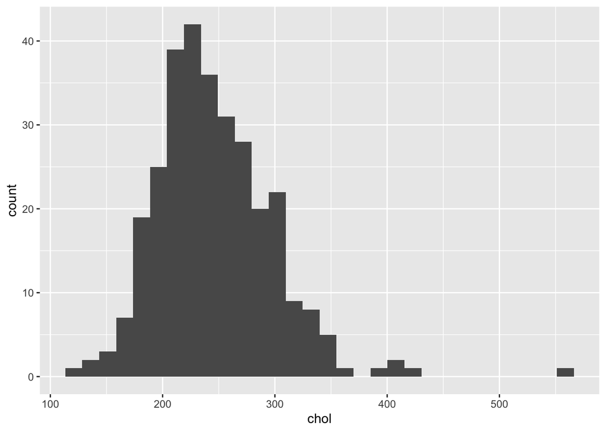

```r
heart %>%
  ggplot(aes(x = chol)) +
  geom_histogram()
```

#### 1b. Describe the distribution’s shape (e.g. left or right skew, normal, etc).

```r
#The distribution’s shape is right skewed
```

### Question 2

#### 2a. Using the age and thalach variables, find their correlation coefficient.

```r
cor <- cor(heart[,1],heart[,8],use='complete',method='pearson')
cor
```

```
##        thalach
## age -0.3985219
```

#### 2b. Show this relationship in a plot.

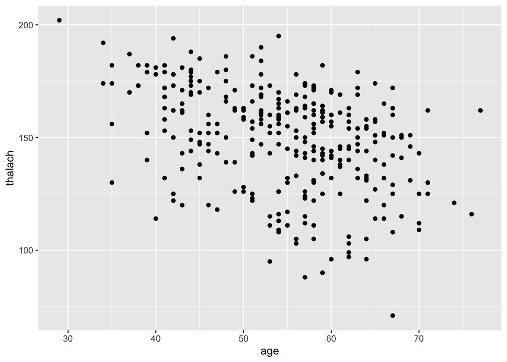

```r
heart %>%
 ggplot(aes(x=age,y=thalach)) +
 geom_point()
```

#### 2c. Does this correlation make sense for this data? Why/why not?

```r
#This correlation makes sense. Because as age increases, human’s physical functions and health reduce, therefore have lower heart rates.
```